# Analysis of RNA-seq data using DEseq2

Stéphane Le Crom, Lucie Gaspard-Boulinc, Matthieu Moreau & Gaëlle Lelandais

August 2024

# 1. Introduction

In their article (Guida et al., 2011), the authors repeated the experiment 6 times for normoxic condition (with O<sub>2</sub>) and 4 times for hypoxic conditions (without O<sub>2</sub>). The results obtained for all experiments are combined in the file “count_data_diffAnalysis.txt”. This file will be used to search for differentially expressed genes using the DESeq2 R package [(Love et al. 2014)](https://genomebiology.biomedcentral.com/articles/10.1186/s13059-014-0550-8).

The [DESeq2 package](http://www.bioconductor.org/packages/release/bioc/html/DESeq2.html) provides methods to test for differential expression by use of the negative binonial distribution and a shrinkage estimator for the distribution’s variance.

Aim: Searching for differentially expressed genes using DESeq R package.

- How many genes are selected with different p-value thresholds (5%, 1%, etc.) ?
- Check your results with IGV and use GOtermFinder to analyse the function of the selected genes.

# 2. Prepare the data for statistical analysis

## Library loading

```r
library(DESeq2)

library(dplyr)
library(reshape2)
library(ggplot2)

#Set ggplot theme as classic
theme_set(theme_classic())
```

## Load the raw count matrix

```r
countData <- read.table("/shared/projects/2420_ens_hts/data/rnaseq/count_data_diffAnalysis_no0counts.txt", row.names = 1, header = TRUE)
```

Visualize some general information: the count matrix stores for each samples (in columns) the number of reads mapped to each ORF (in rows) counted using **bedtools multicov**

```r
# Print the first 10 row names (ORF)
row.names(countData)[1:10]
```

```
##  [1] "CPAR2_404750" "CPAR2_212570" "CPAR2_302130" "CPAR2_209760" "CPAR2_403260"
##  [6] "CPAR2_209040" "CPAR2_804040" "CPAR2_211500" "CPAR2_102540" "CPAR2_109950"
```

You can see that the first 4 samples correspond to the 4 **biological replicates** of the anoxic conditions while there are 6 replicates for the normoxic condition

```r
# Print samples name
colnames(countData)
```

```
##  [1] "noO2rep1" "noO2rep2" "noO2rep3" "noO2rep4" "O2rep1"   "O2rep2"
##  [7] "O2rep3"   "O2rep4"   "O2rep5"   "O2rep6"
```

```r
head(countData)
```

```
##              noO2rep1 noO2rep2 noO2rep3 noO2rep4 O2rep1 O2rep2 O2rep3 O2rep4
## CPAR2_404750      607      318      461      619    481    487    584    561
## CPAR2_212570      536      257      437      496    633    457    552    648
## CPAR2_302130       24        9       14       14      1      6     10      8
## CPAR2_209760      877      315      550     1207   1400    735    922   1186
## CPAR2_403260     2896      740     3019     2619   1951   1858   2615   2365
## CPAR2_209040      860      258      258      730    289    390    572    452
##              O2rep5 O2rep6
## CPAR2_404750    626    642
## CPAR2_212570    984    721
## CPAR2_302130     11      8
## CPAR2_209760   1585   1328
## CPAR2_403260   5065   3185
## CPAR2_209040    329    372
```

## Load metadata of the experiment (design matrix)

The **design** matrix store the information about the biological condition associated to each samples: N = Normoxic condition (with O<sub>2</sub>) H = Hypoxic condition (without O<sub>2</sub>)

```r
colData <- read.table("/shared/projects/2420_ens_hts/data/rnaseq/design.txt", row.names = 1, header = TRUE)

colData
```

```
##          condition
## noO2rep1         H
## noO2rep2         H
## noO2rep3         H
## noO2rep4         H
## O2rep1           N
## O2rep2           N
## O2rep3           N
## O2rep4           N
## O2rep5           N
## O2rep6           N
```

## Creation of the DEseq2’s specific object **DESeqDataSet**

DEseq2 use a specific format to store all the data required to perform the DE analysis. All the results of our analysis will also be stored in specific slots of this object.

```r
dds <- DESeqDataSetFromMatrix(countData = countData,
                             colData = colData,
                             design = ~condition)
```

Using head, you can obtain information about the structure of the object to know where information are stored

```r
head(dds)
```

```
## class: DESeqDataSet
## dim: 6 10
## metadata(1): version
## assays(1): counts
## rownames(6): CPAR2_404750 CPAR2_212570 ... CPAR2_403260 CPAR2_209040
## rowData names(0):
## colnames(10): noO2rep1 noO2rep2 ... O2rep5 O2rep6
## colData names(1): condition
```

For instance, the raw count matrix is available using: **counts()**

```r
head(counts(dds))
```

```
##              noO2rep1 noO2rep2 noO2rep3 noO2rep4 O2rep1 O2rep2 O2rep3 O2rep4
## CPAR2_404750      607      318      461      619    481    487    584    561
## CPAR2_212570      536      257      437      496    633    457    552    648
## CPAR2_302130       24        9       14       14      1      6     10      8
## CPAR2_209760      877      315      550     1207   1400    735    922   1186
## CPAR2_403260     2896      740     3019     2619   1951   1858   2615   2365
## CPAR2_209040      860      258      258      730    289    390    572    452
##              O2rep5 O2rep6
## CPAR2_404750    626    642
## CPAR2_212570    984    721
## CPAR2_302130     11      8
## CPAR2_209760   1585   1328
## CPAR2_403260   5065   3185
## CPAR2_209040    329    372
```

# 3. Normalization

Normalization is a necessary step to correct for different sequencing depth between samples. As you can see their is significant differences between total number of reads obtained for each samples.

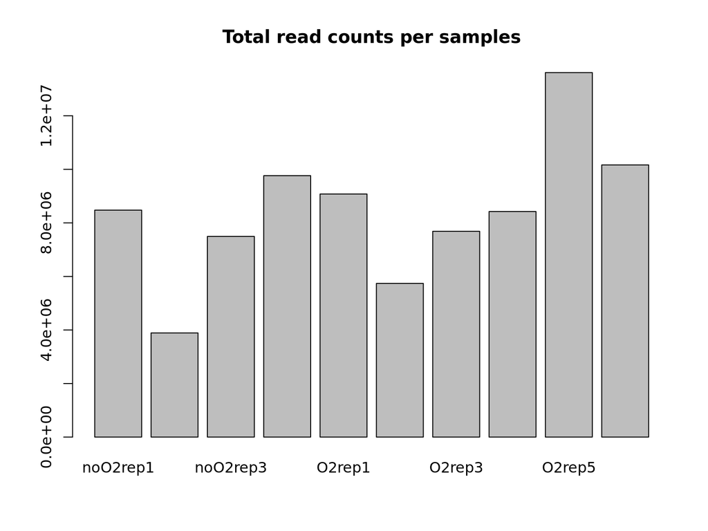

```r
# Bar plots
barplot(colSums(counts(dds)), main = "Total read counts per samples")
```

## Calculation of the size factor

Calculation of the size factor for each sample, which will be use as a correcting factor for sequencing depth (by dividing the raw counts by the size factors).

```r
dds <- estimateSizeFactors(dds)
sizeFactors(dds)
```

```
##  noO2rep1  noO2rep2  noO2rep3  noO2rep4    O2rep1    O2rep2    O2rep3    O2rep4
## 1.0032672 0.4149502 0.7813992 1.1207499 1.1734090 0.8409439 1.1246014 1.1915117
##    O2rep5    O2rep6
## 1.6880443 1.3096478
```

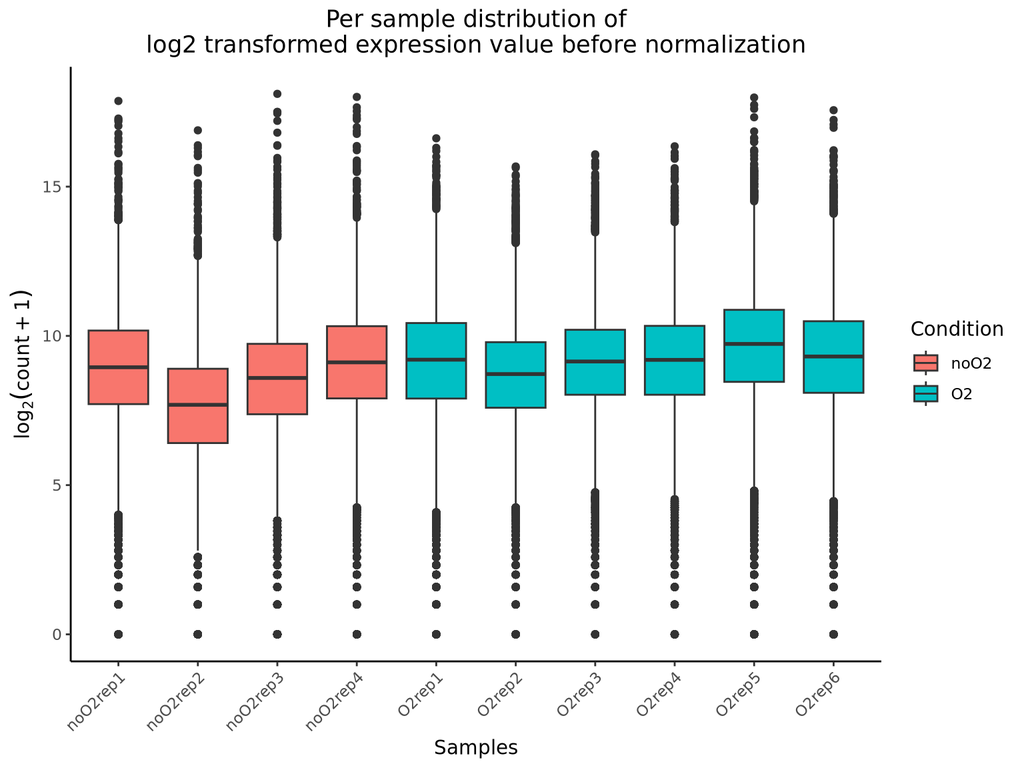

```r
# Raw data
Raw.data <- melt(log2(counts(dds)+1))
colnames(Raw.data) <- c("ORF", "Samples","Expr.Val")
Raw.data <- data.frame(Raw.data,
                 Condition = c(substr(Raw.data$Samples[1:(4*5788)], 1, 4),
                               substr(Raw.data$Samples[(4*5788+1):nrow(Raw.data)], 1, 2)))

ggplot(Raw.data, aes(x = Samples, y = Expr.Val, fill = Condition)) +
  geom_boxplot() +
  ylab(expression(log[2](count + 1))) +
  ggtitle(label = "Per sample distribution of\nlog2 transformed expression value before normalization")+
  theme(axis.text.x=element_text(angle=45, hjust=1))+
  theme(plot.title = element_text(hjust = 0.5))
```

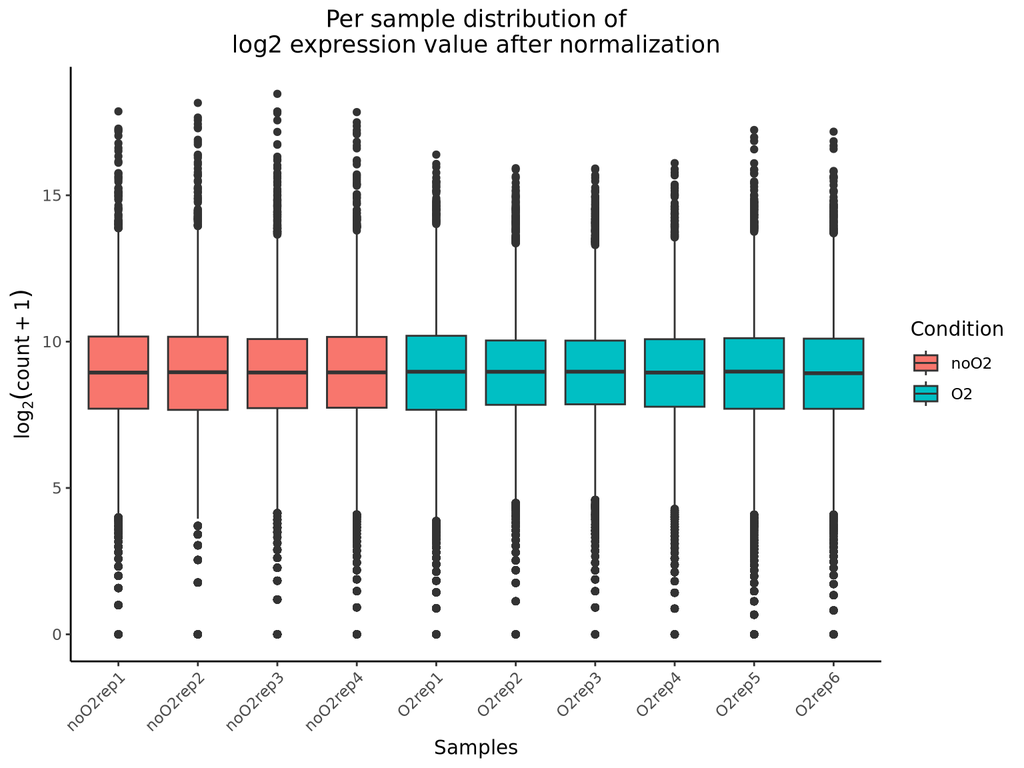

```r
# Normalized data
Norm.data <- melt(log2(counts(dds, normalized=TRUE)+1))
colnames(Norm.data) <- c("ORF", "Samples","Expr.Val")
Norm.data <- data.frame(Norm.data,
                 Condition = c(substr(Norm.data$Samples[1:(4*5788)], 1, 4),
                               substr(Norm.data$Samples[(4*5788+1):nrow(Norm.data)], 1, 2)))


ggplot(Norm.data, aes(x = Samples, y = Expr.Val, fill = Condition)) +
  geom_boxplot() +
  ylab(expression(log[2](count + 1))) +
  ggtitle(label = "Per sample distribution of\nlog2 expression value after normalization") +
  theme(axis.text.x=element_text(angle=45, hjust=1))+
  theme(plot.title = element_text(hjust = 0.5))
```

You can access the normalized count matrix using:

```r
head(counts(dds, normalized=TRUE))
```

```
##                noO2rep1   noO2rep2   noO2rep3   noO2rep4       O2rep1
## CPAR2_404750  605.02327  766.35696  589.96736  552.30876  409.9167545
## CPAR2_212570  534.25449  619.35138  559.25322  442.56082  539.4538579
## CPAR2_302130   23.92184   21.68935   17.91658   12.49164    0.8522178
## CPAR2_209760  874.14401  759.12717  703.86561 1076.95747 1193.1048989
## CPAR2_403260 2886.56903 1783.34637 3863.58232 2336.82818 1662.6768984
## CPAR2_209040  857.19937  621.76130  330.17696  651.34959  246.2909398
##                   O2rep2     O2rep3     O2rep4      O2rep5      O2rep6
## CPAR2_404750  579.111133  519.29512  470.83047  370.843350  490.208123
## CPAR2_212570  543.436936  490.84059  543.84696  582.923094  550.529684
## CPAR2_302130    7.134839    8.89204    6.71416    6.516417    6.108512
## CPAR2_209760  874.017829  819.84606  995.37422  938.956406 1014.013065
## CPAR2_403260 2209.421940 2325.26839 1984.87355 3000.513688 2431.951516
## CPAR2_209040  463.764562  508.62467  379.35004  194.900099  284.045829
```

## PCA of samples

```r
vsd <- varianceStabilizingTransformation(dds, blind=TRUE)
```

```
## using ntop=500 top features by variance
```

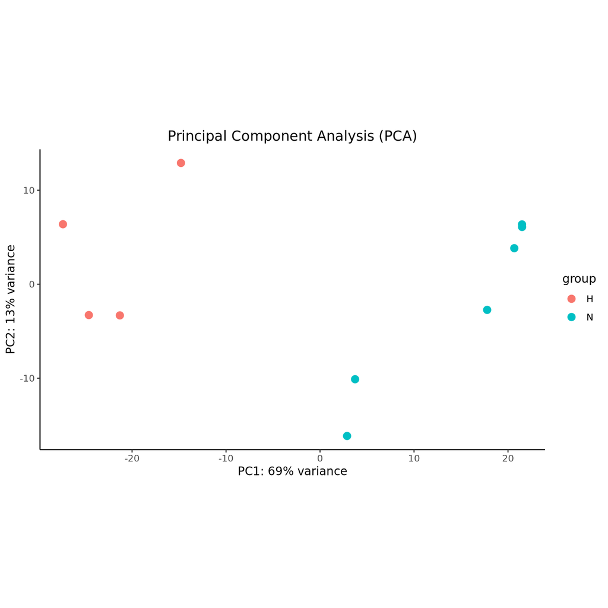

```r
# PCA plot
plotPCA(vsd) +
  ggtitle(label = "Principal Component Analysis (PCA)") +
  theme(plot.title = element_text(hjust = 0.5))
```

# 4. Differential expression analysis

## Variance/Dispersion estimation

```r
dds <- estimateDispersions(dds)
```

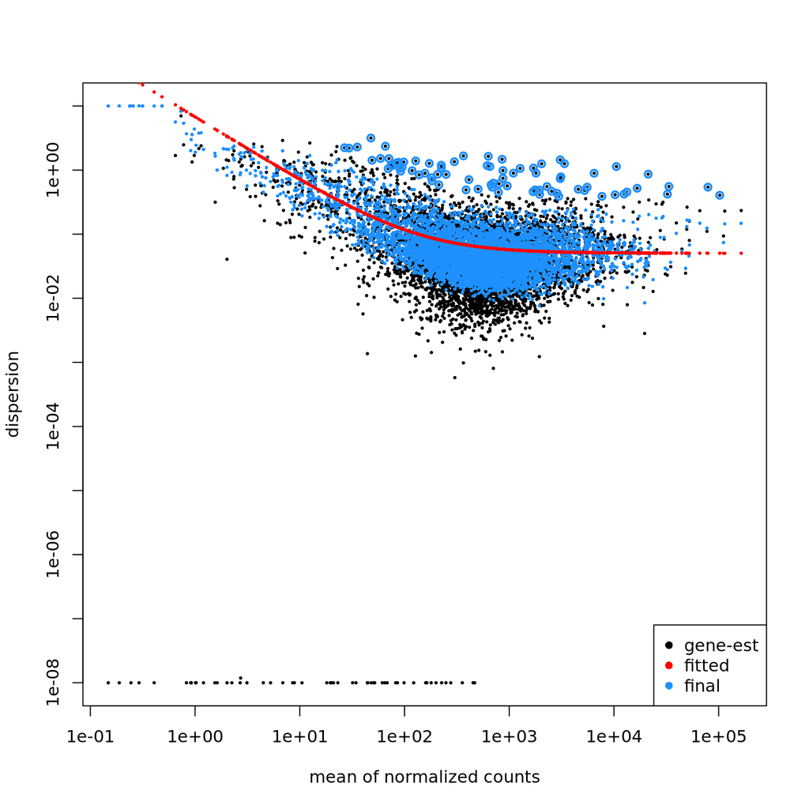

```r
plotDispEsts(dds)
```

## Negative binomial wald test implemented by DEseq2

```r
dds <- nbinomWaldTest(dds)
```

## Retrieve the result table

```r
res <- results(dds, contrast=c("condition","H","N"))
head(res)
```

```
## log2 fold change (MLE): condition H vs N
## Wald test p-value: condition H vs N
## DataFrame with 6 rows and 6 columns
##               baseMean log2FoldChange     lfcSE      stat     pvalue      padj
##              <numeric>      <numeric> <numeric> <numeric>  <numeric> <numeric>
## CPAR2_404750  535.3861      0.4056168  0.168628  2.405389 0.01615524 0.0405212
## CPAR2_212570  540.6451     -0.0164868  0.128962 -0.127841 0.89827441 0.9366682
## CPAR2_302130   11.2238      1.6472390  0.556416  2.960445 0.00307195 0.0103797
## CPAR2_209760  924.9407     -0.1855940  0.166547 -1.114365 0.26512276 0.3816501
## CPAR2_403260 2448.5032      0.2607853  0.229521  1.136218 0.25586548 0.3710017
## CPAR2_209040  453.7463      0.8316175  0.315945  2.632161 0.00848436 0.0242099
```

```r
# Generate a summary
summary(res)
```

```
##
## out of 5788 with nonzero total read count
## adjusted p-value < 0.1
## LFC > 0 (up)       : 1412, 24%
## LFC < 0 (down)     : 1431, 25%
## outliers [1]       : 4, 0.069%
## low counts [2]     : 0, 0%
## (mean count < 0)
## [1] see 'cooksCutoff' argument of ?results
## [2] see 'independentFiltering' argument of ?results
```

Take a look at the *log2FoldChange*. **What is the orientation of the calculated log2FC?**

```r
# Using "mcols()" you can obtain a description of the result information stored in columns
mcols(res, use.names=TRUE)
```

```
## DataFrame with 6 rows and 2 columns
##                        type            description
##                 <character>            <character>
## baseMean       intermediate mean of normalized c..
## log2FoldChange      results log2 fold change (ML..
## lfcSE               results standard error: cond..
## stat                results Wald statistic: cond..
## pvalue              results Wald test p-value: c..
## padj                results   BH adjusted p-values
```

```r
# Display the whole column description
res@elementMetadata@listData[["description"]]
```

```
## [1] "mean of normalized counts for all samples"
## [2] "log2 fold change (MLE): condition H vs N"
## [3] "standard error: condition H vs N"
## [4] "Wald statistic: condition H vs N"
## [5] "Wald test p-value: condition H vs N"
## [6] "BH adjusted p-values"
```

Convert res into data frame

```r
res <- as.data.frame(res)
```

## Diagnostic plots

### Histogram of the p values

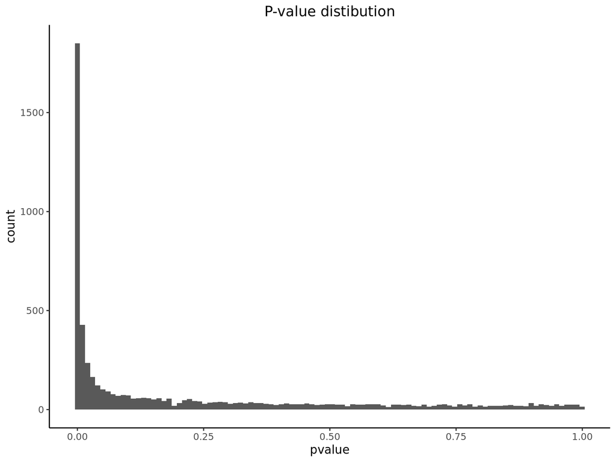

```r
ggplot(res, aes(x = pvalue)) +
  geom_histogram(bins = 100) +
  ggtitle(label = "P-value distibution") +
  theme(plot.title = element_text(hjust = 0.5))
```

### Volcan plot

We will draw a Volcano plot using the [EnhanceVolcano Bioconductor package](https://bioconductor.org/packages/release/bioc/html/EnhancedVolcano.html)

```r
# EnhanceVolcano library loading
library(EnhancedVolcano)
```

```r
# Threshold selection
logFCthreshold <- 2
adjPVthreshold <- 0.01
```

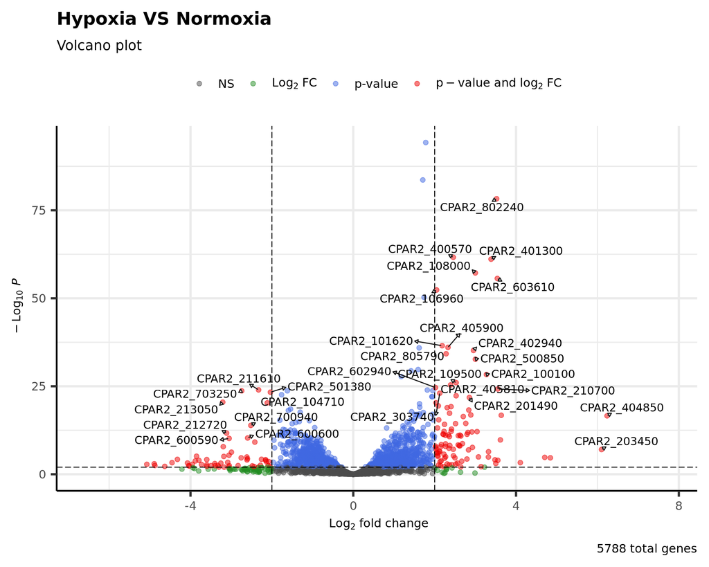

```r
# Volcano plot drawing
EnhancedVolcano(res,
    lab = rownames(res),
    x = 'log2FoldChange',
    y = 'padj',
    axisLabSize = 12,
    ylim = c(0,max(-log10(res[[6]]))),
    caption = paste0(nrow(res), " total genes"),
    captionLabSize = 12,
    FCcutoff = logFCthreshold,
    pCutoff = adjPVthreshold,
    title = 'Hypoxia VS Normoxia',
    subtitle = 'Volcano plot',
    pointSize = 2.0,
    labSize = 4.0,
    legendLabSize = 12,
    legendIconSize = 2.0,
    drawConnectors = TRUE)
```

You can use the option “selectLab” to display only the genes you are interested in on the graph passing a vector of gene names.

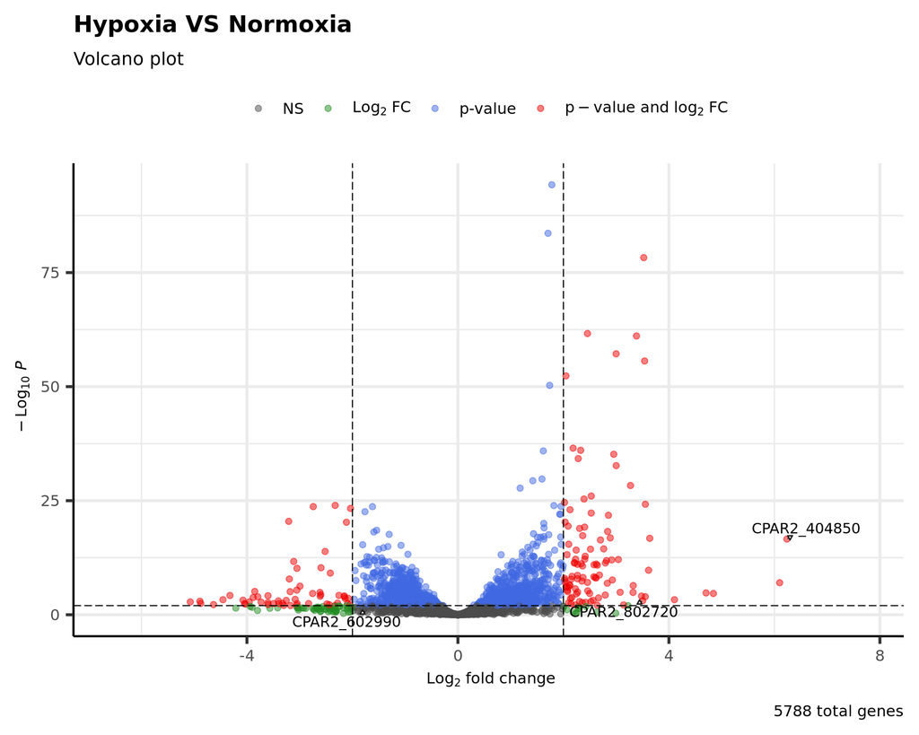

```r
# Volcano plot drawing
EnhancedVolcano(res,
    lab = rownames(res),
    x = 'log2FoldChange',
    y = 'padj',
    selectLab = c('CPAR2_404850','CPAR2_602990', 'CPAR2_802720'),
    axisLabSize = 12,
    ylim = c(0,max(-log10(res[[6]]))),
    caption = paste0(nrow(res), " total genes"),
    captionLabSize = 12,
    FCcutoff = logFCthreshold,
    pCutoff = adjPVthreshold,
    title = 'Hypoxia VS Normoxia',
    subtitle = 'Volcano plot',
    pointSize = 2.0,
    labSize = 4.0,
    legendLabSize = 12,
    legendIconSize = 2.0,
    drawConnectors = TRUE)
```

### MA plot

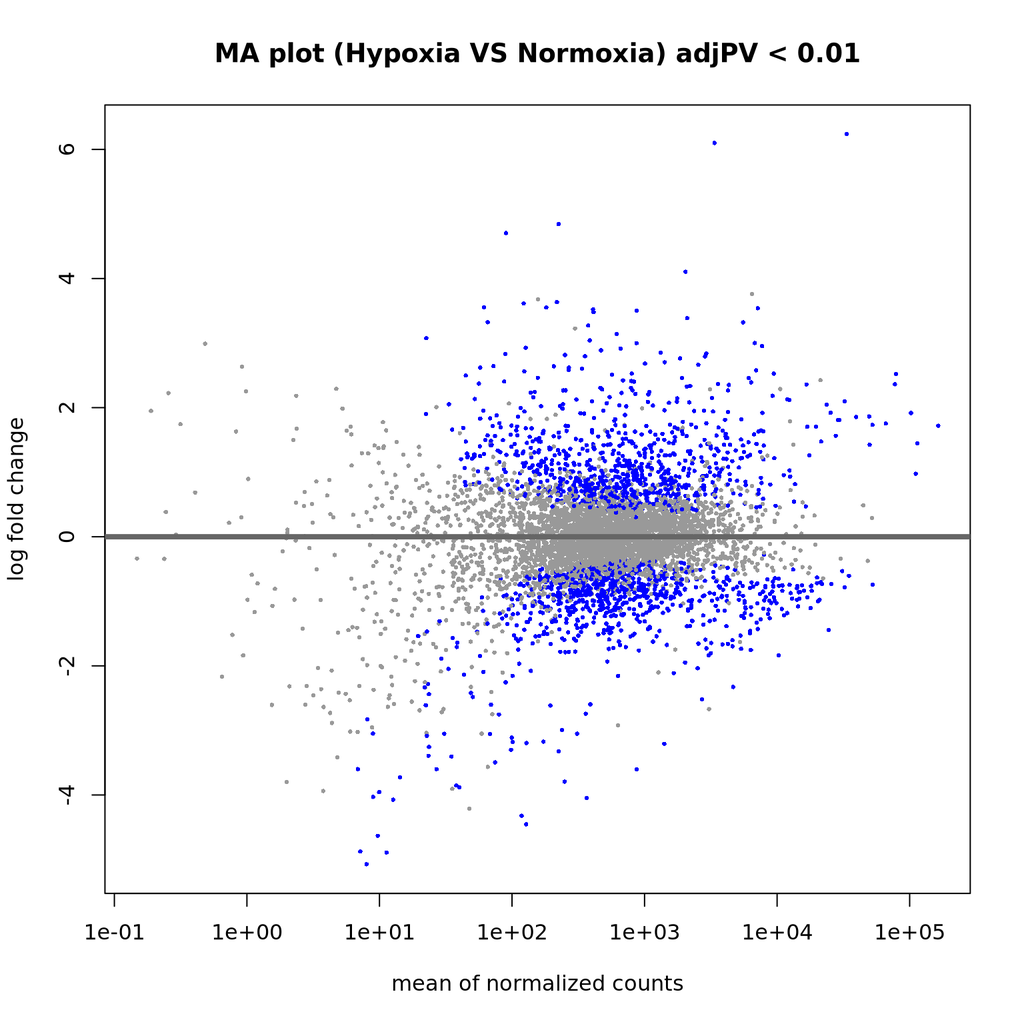

```r
plotMA(results(dds, contrast=c("condition","H","N")),
       alpha = adjPVthreshold,
       main = paste("MA plot (Hypoxia VS Normoxia) adjPV <",adjPVthreshold),
       ylim=c(min(na.omit(res[[2]])),max(na.omit(res[[2]]))))
```

## Export results

Genes with log2FoldChange > 2 and padj < 0.01

```r
FoldFc_pos <- res[res$log2FoldChange > logFCthreshold & res$padj < adjPVthreshold,]

paste(nrow(FoldFc_pos), "upregulated genes in Hypoxia")
```

```
## [1] "104 upregulated genes in Hypoxia"
```

```r
# To save the result in your home working directory
write.table(FoldFc_pos, row.names = T, quote = F, sep = ";", file = "~/RNAseq_FoldFc_pos.csv")
```

Genes with log2FoldChange < -2 and padj < 0.01

```r
FoldFc_neg <- res[res$log2FoldChange <(-logFCthreshold) & res$padj < adjPVthreshold,]

paste(nrow(FoldFc_neg), "upregulated genes in Normaxia")
```

```
## [1] "57 upregulated genes in Normaxia"
```

```r
# To save the result in your home working directory
write.table(FoldFc_neg, row.names = T, quote = F, sep = ";", file = "~/RNAseq_FoldFc_neg.csv")
```

# 5. Functional analyzes of differentially expressed genes

Several tools are available online to evaluate the biological relevance of the gene sets you select after the differential analysis. For example you can you use the [GoTermFinder tool] (http://www.candidagenome.org/cgi-bin/GO/goTermFinder) dedicated to *Candida* yeast species to retrieve functional annotation. You can also obtain information on a specific gene using the [Candida Genome Database](http://www.candidagenome.org/).

What are the functions of the genes in your lists (identified at the previous step).

- Are they relevant with the studied biological system described by Guida et al. in their publication?

# Reproductibility

```r
# Date
format(Sys.time(), "%d %B, %Y, %H,%M")
```

```
## [1] "20 August, 2024, 15,21"
```